# week15

b06208016楊鎧綾

December 21, 2018

## 4.12

### a

derived every row value by every row total, then we can get the row percent which means depend on their sex what the answer they will answer, so the sex of a person is explanatory variable

### b

```r
right_p=c(87/129,64/83,151/212)
over_p=c(39/129,3/83,42/212)
under_p=c(3/129,16/83,19/212)
total_p=c(1,1,1)
p=data.frame(about_right=right_p,overweight=over_p,underweight=under_p,total=total_p,row.names = c("female","male","total"))
p
```

```
##        about_right overweight underweight total
## female   0.6744186 0.30232558  0.02325581     1
## male     0.7710843 0.03614458  0.19277108     1
## total    0.7122642 0.19811321  0.08962264     1
```

### c

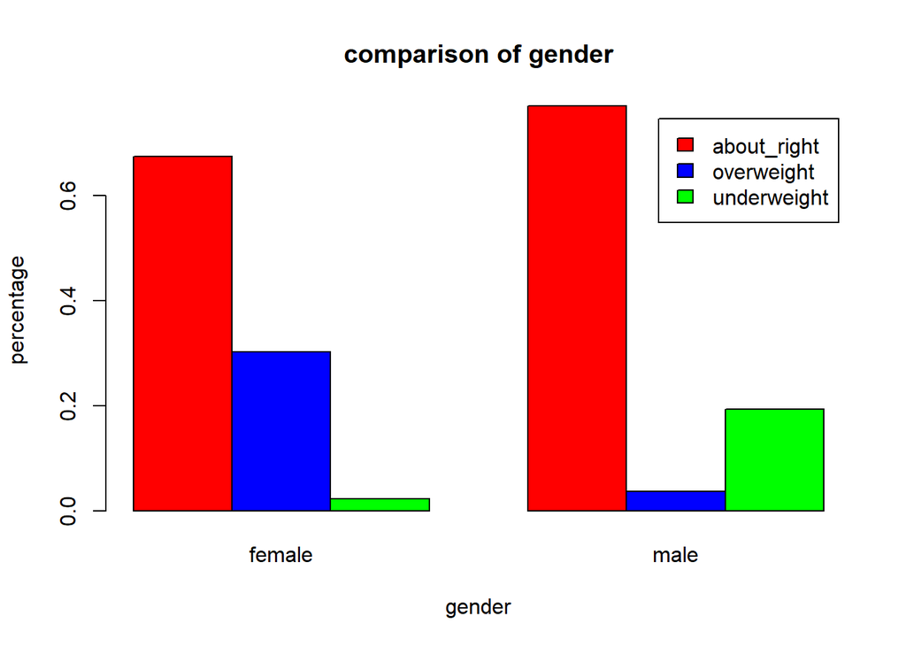

```r
pp=t(as.matrix(p))
pp=pp[1:3,1:2]
barplot(pp,col=c("red","blue","green"),main="comparison of gender",xlab = "gender",ylab="percentage",legend=rownames(pp),beside = T)
```

### d

female are more likely to think themselves overweight, and male are more likely to think themselves underweight, even though most of people think themselves about right

### e

it is the data of a collage statistic class, the population it can infer is **collage students**, because it cannot overestimate other ages

## 4.26

### data

```r
YES=c(42,30,72)
NO=c(50,87,137)
TOTAL=c(92,117,209)
data.frame(YES,NO,TOTAL,row.names = c('short','tall','total'))
```

```
##       YES  NO TOTAL
## short  42  50    92
## tall   30  87   117
## total  72 137   209
```

### a

```r
risk_s=42/92;risk_s
```

```
## [1] 0.4565217
```

```r
risk_t=30/117;risk_t
```

```
## [1] 0.2564103
```

the risk of short people being bullied is 0.46;and the risk for tall people is 0.26

### b

```r
r_risk=risk_s/risk_t;r_risk
```

```
## [1] 1.780435
```

the relative risk for short student being bullied with the basedline is tall students being bullied is 1.78,  
which means short students is 1.78 times more likely to being bullied than tall students

### c

```r
r_risk-1
```

```
## [1] 0.7804348
```

the increased risk of having been bullied for short students is 0.78,  
which means compare to tall students the increase the risk of 0.78 to be bullied

### d

```r
odd_s=42/50
odd_t=30/87
odd_ratio=odd_s/odd_t;odd_ratio
```

```
## [1] 2.436
```

the odds ratio is 2.436;which means the odds of short students being bullied is 2.436 times than tall students

## 4.36

### data

```r
survive=c(5,100,105)
die=c(95,900,995)
TOTAL=c(100,1000,1100)
a=data.frame(survive,die,TOTAL,row.names = c('standard','new','total'))
a
```

```
##          survive die TOTAL
## standard       5  95   100
## new          100 900  1000
## total        105 995  1100
```

```r
survive=c(500,95,595)
die=c(500,5,505)
TOTAL=c(1000,100,1100)
b=data.frame(survive,die,TOTAL,row.names = c('standard','new','total'))
b
```

```
##          survive die TOTAL
## standard     500 500  1000
## new           95   5   100
## total        595 505  1100
```

### a

```r
a[1,1]/a[1,3]
```

```
## [1] 0.05
```

```r
a[2,1]/a[2,3]
```

```
## [1] 0.1
```

new treatment is more successful in hospital A, the survival of new treatment is 0.1 is higher than standard treatment which the survival rate is 0.05

### b

```r
b[1,1]/b[1,3]
```

```
## [1] 0.5
```

```r
b[2,1]/b[2,3]
```

```
## [1] 0.95
```

new treatment is more successful in hospital B, the survival of new treatment is 0.95 is higher than standard treatment which the survival rate is 0.5

### c

```r
c=a+b
c
```

```
##          survive  die TOTAL
## standard     505  595  1100
## new          195  905  1100
## total        700 1500  2200
```

```r
c[1,1]/c[1,3]
```

```
## [1] 0.4590909
```

```r
c[2,1]/c[2,3]
```

```
## [1] 0.1772727
```

### d

**because the sample size is different in two hospital**,  
the survival rate is lower in hospital A, even though it has higher survival rate in new treatment but its survival rate is really low, so it would pull down the survival rate of combine one, and hospital B would push up the survival rate of standard treatment

## 15.18

### a

step.1  
$H_0:$ smoking or not have no relationship with separated or not  
$H_a:$ smoking and separated has relationship

### b

step.2 the sample is big enough, all of them are bigger than 1, and at least 80% of them bigger than 5

```r
separated=c(41,41,32,114)
not=c(931,290,163,1384)
TOTAL=c(972,331,195,1498)
a=data.frame(separated,not,TOTAL,row.names = c('neither smoked','one smoked','both smoked','total'))
a
```

```
##                separated  not TOTAL
## neither smoked        41  931   972
## one smoked            41  290   331
## both smoked           32  163   195
## total                114 1384  1498
```

calculate the chi-squared is 48.125

```r
exp_separated=c(972*114/1498,331*114/1498,195*114/1498)
exp_not=c(972*1384/1498,331*1384/1498,195*1384/1498)
exp=data.frame(exp_separated,exp_not,row.names = c("neither","one","both"))
exp
```

```
##         exp_separated  exp_not
## neither      73.97063 898.0294
## one          25.18959 305.8104
## both         14.83979 180.1602
```

```r
a=a[1:3,1:2];a
```

```
##                separated not
## neither smoked        41 931
## one smoked            41 290
## both smoked           32 163
```

```r
chi=(a-exp)^2/exp;chi
```

```
##                separated       not
## neither smoked 14.695864 1.2104975
## one smoked      9.923513 0.8173992
## both smoked    19.843475 1.6345059
```

```r
chi=sum(chi)
chi
```

```
## [1] 48.12525
```

step.3 find the p-value is 3.545964e-11

```r
df=(3-1)*(2-1)
p.value=1-pchisq(chi,df=df)
p.value
```

```
## [1] 3.545964e-11
```

step.4 under 95% confidence level the alpha=0.05,**the p-value is smaller than alpha, so we can reject null hypothesis**  
step.5 so we can say that smoking and separated has relationship

## 15.26

### data

```r
always=c(964,924,1888)
never=c(97,254,351)
TOTAL=c(1061,1178,2239)
a=data.frame(always,never,TOTAL,row.names = c('female','male','total'))
a
```

```
##        always never TOTAL
## female    964    97  1061
## male      924   254  1178
## total    1888   351  2239
```

### a

step.1  
$H_0:$ sex have no relationship with using seatbelt  
$H_a:$ sex have relationship with using seatbelt

step.2 the sample is big enough, all of them are bigger than 1, and at least 80% of them bigger than 5,we calculate the chi-square

```r
chi.square=(a[3,3]*(a[1,1]*a[2,2]-a[1,2]*a[2,1])^2)/(a[1,3]*a[2,3]*a[3,1]*a[3,2])
chi.square
```

```
## [1] 65.1365
```

### b

step.3

```r
df=(2-1)*(2-1);df
```

```
## [1] 1
```

the degree of freedom is 1

### c

```r
p.value=1-pchisq(chi.square,df=df)
p.value
```

```
## [1] 6.661338e-16
```

the p-value is 6.661338e-16

### d

step.4 under the confidence level of 95% we get the $\alpha=0.05$ ,**the p-value is smaller than alpha, so we can reject null hypothesis**  
step.5 so we can say that sex and using seatbelt has relationship

## 15.40

### data

```r
groups=c("sliver","blue","green","total")
times=c(59,25,27,111)
expected=c((1/3)*111,(1/3)*111,(1/3)*111,111)
a=data.frame(groups,times,expected)
a
```

```
##   groups times expected
## 1 sliver    59       37
## 2   blue    25       37
## 3  green    27       37
## 4  total   111      111
```

step.1  
$H_0:$the probability is the same for picking all the colors  
$H_a:$ the probability is not the same for picking all the colors

step.2 the sample is big enough, all of them are bigger than 1, and at least 80% of them bigger than 5,we calculate the chi-square is 19.67568

```r
c=a[1:3,2]
exp=a[1:3,3]
chi=((c-exp)^2)/exp
chi=sum(chi)
chi
```

```
## [1] 19.67568
```

step.3

```r
df=3-1;df
```

```
## [1] 2
```

the degree of freedom is 2

```r
p.value=1-pchisq(chi,df=df)
p.value
```

```
## [1] 5.339263e-05
```

the p-value is 5.339263e-05

step.4 under the confidence level of 95% we get the $\alpha=0.05$ ,**the p-value is smaller than alpha, so we can reject null hypothesis**  
step.5 so we can say that the probability is not the same for picking all the colors

## r studio

### HW1 Write a function for Chi-square test (2*2)

```r
Heart_Table = read.table("heartatk.csv", header=TRUE, sep=",")
MyTable = xtabs(~ SEX + DIED, data = Heart_Table) # generate a 2x2 table
MyTable
```

```
##    DIED
## SEX    0    1
##   F 4298  767
##   M 7136  643
```

```r
MyChiSq <- function(MyTable) {
    # row total, column total, total
    total.0 = sum(MyTable[,1])
    total.1 = sum(MyTable[,2])
    total.F = sum(MyTable[1,])
    total.M = sum(MyTable[2,])
    total = sum(MyTable)

    # generate an expected table
    ExpTable = MyTable
    ExpTable[1,1] = total.0*total.F / total
    ExpTable[1,2] = total.1*total.F / total
    ExpTable[2,1] = total.0*total.M / total
    ExpTable[2,2] = total.1*total.M / total

    # calculate chi-square statistic
    chi.11 = ((MyTable[1,1] - ExpTable[1,1])^2) / ExpTable[1,1]
    chi.12 = ((MyTable[1,2] - ExpTable[1,2])^2) / ExpTable[1,2]
    chi.21 = ((MyTable[2,1] - ExpTable[2,1])^2) / ExpTable[2,1]
    chi.22 = ((MyTable[2,2] - ExpTable[2,2])^2) / ExpTable[2,2]
    chi.square = sum(chi.11, chi.12, chi.21, chi.22)

    # p-value
    df = (nrow(MyTable)-1) * (ncol(MyTable)-1)
    p.value = 1-pchisq(chi.square, df = df)
    results=list(X.squared = chi.square, df = df, p.value = p.value)
    return(results)

}


MyChiSq(MyTable)
```

```
## $X.squared
## [1] 148.4641
##
## $df
## [1] 1
##
## $p.value
## [1] 0
```

### HW2

step.1  
$H_0:$the probability is binomial distribution  
$H_a:$ the probability is not binomial distribution

step.2 check whether the sample is big enough, all of them are bigger than 1, and at least 80% of them bigger than 5,if true calculate the chi-square is 4.006

```r
x = c(0,1,2,3,4,5,6,7)

#observed values
obs = c(5,13,26,19,20,7,0,0)
n = 90
pp =(sum(x*obs))/(n*7)#下雨的機率

#expected values
exp = c()
for (i in 1:length(obs)) {
  exp[i] = dbinom(x[i],size=7,pp)* n
}

tbl = data.frame(x, obs, exp)

#check conditions
#combining 6,7,8 rows
tbl.678 = tbl[6,] + tbl[7,] + tbl[8,] #add up 6,7,8 rows
tbl = tbl[-c(6,7,8),] #remove 6,7,8 rows
tbl = rbind(tbl, tbl.678) #add the combined row

#calculate the chi-square statistic
chi=(tbl$obs-tbl$exp)^2/tbl$exp
x_square=sum(chi)
x_square
```

```
## [1] 4.006201
```

step.3

```r
df = nrow(tbl)-1-1 #k-1-r r為推估的參數數
df
```

```
## [1] 4
```

the degree of freedom is 4

```r
p.value=1-pchisq(x_square,df=df)
p.value
```

```
## [1] 0.4051673
```

the p-value is 0.405

step.4 under the confidence level of 95% we get the $\alpha=0.05$ ,**the p-value is bigger than alpha, so we cannot reject null hypothesis**

```r
alpha = 0.05
if (p.value <= alpha) {
  print("Reject H0.")
} else {
  print("Do not reject H0.")
}
```

```
## [1] "Do not reject H0."
```

step.5 so we can say that the probability is binomial distribution

### HW3

step.1  
$H_0:$the probability is normal distribution  
$H_a:$ the probability is not normal distribution

```r
pm2.5 = c(18.8, 14.6, 14.0, 15.8, 12.4, 13.2, 16.1, 13.8, 16.2,
          16.1, 17.8, 18.7, 15.8, 13.3, 13.6, 16.4, 13.8, 16.6,
          15.3, 19.0, 18.4, 15.0, 18.8, 18.1, 17.3, 16.3, 17.5,
          18.1, 14.2, 18.0, 13.0, 13.3, 12.4, 16.6, 14.1, 20.6,
          16.8, 13.3, 18.2, 16.9)

#defining thresholds to categorize continuous data
mean = mean(pm2.5)
sd = sd(pm2.5)
n = length(pm2.5)

thres = c(mean-3*sd, mean-2*sd, mean-sd, mean, mean+sd, mean+2*sd, mean+3*sd)

#observed values (continuous --> discrete)
obs = rep(0, length = 8)

for (i in 1:length(pm2.5)) {
  if (pm2.5[i] < thres[1]) {
    obs[1]=obs[1]+1
  } else if (thres[1]<pm2.5[i] & pm2.5[i] <thres[2]) {
    obs[2]=obs[2]+1
  } else if (thres[2]<pm2.5[i] & pm2.5[i]<thres[3]) {
    obs[3]=obs[3]+1
  }else if (thres[3]<pm2.5[i] & pm2.5[i]<thres[4]) {
    obs[4]=obs[4]+1
  }else if (thres[4]<pm2.5[i] & pm2.5[i]<thres[5]) {
    obs[5]=obs[5]+1
  }else if (thres[5]<pm2.5[i] & pm2.5[i]<thres[6]) {
    obs[6]=obs[6]+1
  }else if (thres[6]<pm2.5[i] & pm2.5[i]<thres[7]) {
    obs[7]=obs[7]+1
  }else {
    obs[8]=obs[8]+1
  }
}


#expected value

cumu.p = c(pnorm(thres[1],mean=mean,sd=sd),
           pnorm(thres[2],mean=mean,sd=sd) - pnorm(thres[1],mean=mean,sd=sd),
           pnorm(thres[3],mean=mean,sd=sd) - pnorm(thres[2],mean=mean,sd=sd),
           pnorm(thres[4],mean=mean,sd=sd) - pnorm(thres[3],mean=mean,sd=sd),
           pnorm(thres[5],mean=mean,sd=sd) - pnorm(thres[4],mean=mean,sd=sd),
           pnorm(thres[6],mean=mean,sd=sd) - pnorm(thres[5],mean=mean,sd=sd),
           pnorm(thres[7],mean=mean,sd=sd) - pnorm(thres[6],mean=mean,sd=sd),
           1-pnorm(thres[7],mean=mean,sd=sd))
exp = cumu.p * n

#creat table
tbl = data.frame(obs, exp)


#check conditions
tbl
```

```
##   obs         exp
## 1   0  0.05399592
## 2   0  0.85600936
## 3  10  5.43620488
## 4   8 13.65378984
## 5  15 13.65378984
## 6   6  5.43620488
## 7   1  0.85600936
## 8   0  0.05399592
```

```r
#combining 6,7,8 rows
tbl.678 = tbl[6,] +tbl[7,] + tbl[8,] #add up 7,8 rows
tbl = tbl[-c(6,7,8),] #remove 7,8 rows
#combining 1,2,3 rows
tbl.123 = tbl[1,] + tbl[2,] + tbl[3,] #add up 1,2,3 rows
tbl = tbl[-c(1,2,3),] #remove 6,7,8 rows
tbl = rbind(tbl.123,tbl, tbl.678) #add the combined row
#add table name
cate = c("< m-d", "m-d ~ m", "m ~ m+d", ">m+d")
rownames(tbl) = cate
tbl
```

```
##         obs      exp
## < m-d    10  6.34621
## m-d ~ m   8 13.65379
## m ~ m+d  15 13.65379
## >m+d      7  6.34621
```

```r
#calculate the chi-square statistic
chi=(tbl$obs -tbl$exp)^2/tbl$exp
x_square=sum(chi)
x_square
```

```
## [1] 4.644864
```

step.3

```r
df = nrow(tbl)-1-2  # k-1-r
df
```

```
## [1] 1
```

the degree of freedom is 1

```r
p.value=1-pchisq(x_square,df=df)
p.value
```

```
## [1] 0.0311466
```

the p-value is 0.0311466

step.4 under the confidence level of 95% we get the $\alpha=0.05$ ,**the p-value is smaller than alpha, so we can reject null hypothesis**

```r
alpha = 0.05
if (p.value <= alpha) {
  print("Reject H0.")
} else {
  print("Do not reject H0.")
}
```

```
## [1] "Reject H0."
```

step.5 so we can say that the probability is not normal distribution